# Schätzung von Verteilungen - Histogramme

01. Juni 2021

## Empirische Schätzung der PDF mit Histogram

- Gegeben sei ein Merkmal ITS mit einer unbekannten Verteilung und die Anzahl der zusetzenden Intervalle NrOfBins

1.) Setze einheitliche Schnittpunkte fest (-> rechte Intervallsgrenze b)

2.) Teile die Variable mit cut() in Intervalle ein (-> linke Intervallsgrenze a)

3.) Zähle mit table() die Anzahl an Datenpunkten je Intervall (a,b]

```r
#Echte Daten
ITS = DataVisualizations::ITS
NrOfBins = 10
MinD = min(ITS)
MaxD = max(ITS)
MinD
```

```
## [1] 43.48
```

```r
MaxD
```

```
## [1] 1620.69
```

```r
Breaks <- seq(MinD, MaxD, abs(MinD - MaxD) / NrOfBins)
#cut divides the range of x into intervals
#table counts at each combination the number
countsPerInt = table(cut(ITS, Breaks))
countsPerInt[1:5]
```

```
##
## (43.5,201]  (201,359]  (359,517]  (517,674]  (674,832]
##        129       2074       2055       3736       2448
```

## Plotte mit Histogram

- Die Wahl geeigneter Intervallgrenzen ist dabei kritisch.
  - Oben: nach eigenener Definition gezeichnet.
  - Unten: hist() mit selbigem NrOfBins setzt die Intervallgrenzen anders.

=> Histogramme zeigen verschiedene Verteilungen.

- Nota: Intervall wird überblicherweise “bin” genannt.

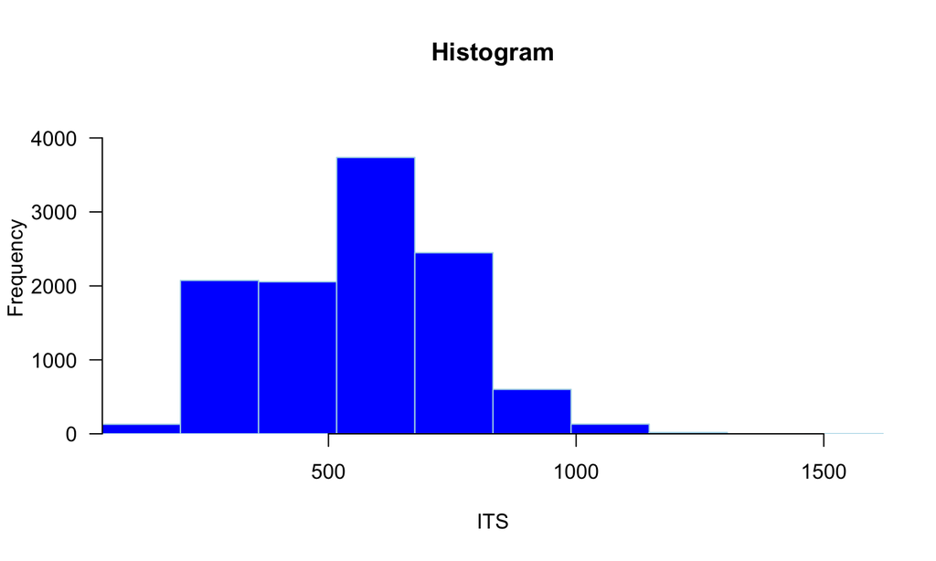

```r
nB <- length(Breaks)
xlab = "ITS"
ylab = "Frequency"
#definiert den Bereicht des Plots vorab
plot(
  x = c(MinD, MaxD),
  y = c(0, max(countsPerInt) * 1.2),
  type = "n",
  main = "Histogram",
  xaxs = "i",
  yaxs = "i",
  axes = FALSE,
  xlab = xlab,
  ylab = ylab,
  xlim = c(MinD, MaxD),
  ylim = c(0, max(countsPerInt) * 1.2)
)
#Zeichnet jeden bin einzeln als gefuelltes rechteck in den Plot
rect(
  Breaks[-nB],
  0,
  Breaks[-1],
  countsPerInt,
  col = "blue",
  border = "light blue",
  xlab = "",
  ylab = ylab,
  xlim = c(MinD, MaxD),
  ylim = c(0,
           max(countsPerInt, na.rm = TRUE) * 1.2)
)
axis(1, col = "black", las = 1, xaxs = "i")
axis(2, col = "black", las = 1, yaxs = "i")
```

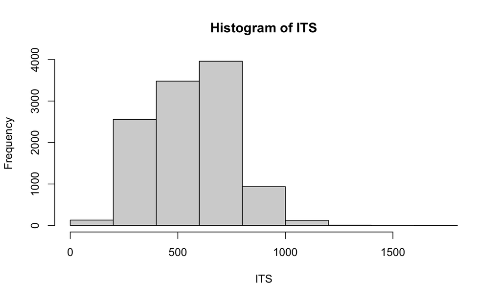

```r
hist(ITS, breaks = NrOfBins)
```

## PDF mit Histogram - Gleichverteilung

-Die Wahl eines geeigneten Radius ist dabei kritisch. - Hier wird der Radius verkleinert indem die Anzahl an Bins vergrößert wird ohne den Radius genauer zu spezifizieren.

- Oben: kleine Anzahl an Bins, d.h. Großer Radius.
- Unten: Große Anzahl an Bins, d.h. kleiner Radius.
- Wir kennen die PDF einer Gleichverteilung

=> Wir wissen die richtige Einstellung von NrOfBins

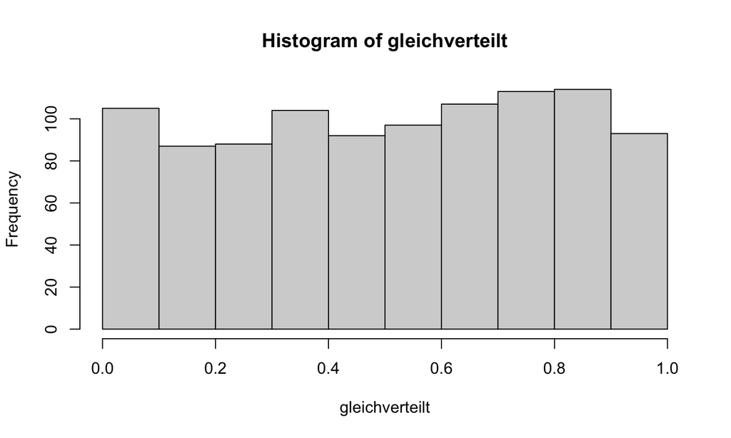

```r
# Gleichverteilung
gleichverteilt=runif(1000,min = 0,max = 1)
NrOfBins=10
hist(gleichverteilt, breaks = NrOfBins)
```

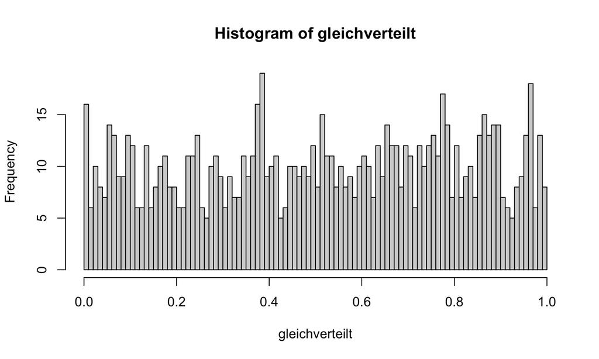

```r
NrOfBins=100
hist(gleichverteilt, breaks = NrOfBins)
```

## PDF mit Histogram - Merkmal X

-Die Wahl eines geeigneten Radius ist dabei kritisch. - Hier wird der Radius verkleinert indem die Anzahl an Bins vergrößert wird ohne den Radius genauer zu spezifizieren.

- Oben: kleine Anzahl an Bins, d.h. Großer Radius.
- Unten: Große Anzahl an Bins, d.h. kleiner Radius.
- Wir wissen aber (noch) nicht wie das Merkmal ITS verteilt ist!

=> Wir kennen die richtige Einstellung von NrOfBins nicht.

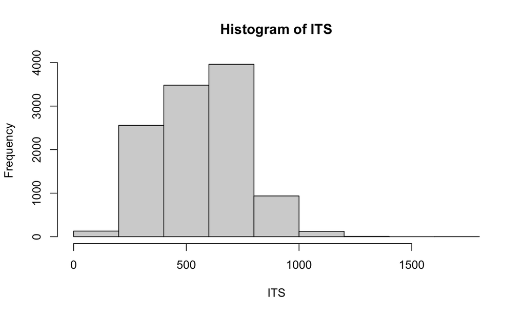

```r
# Ubekannte Variable
NrOfBins=10
hist(ITS, breaks = NrOfBins)
```

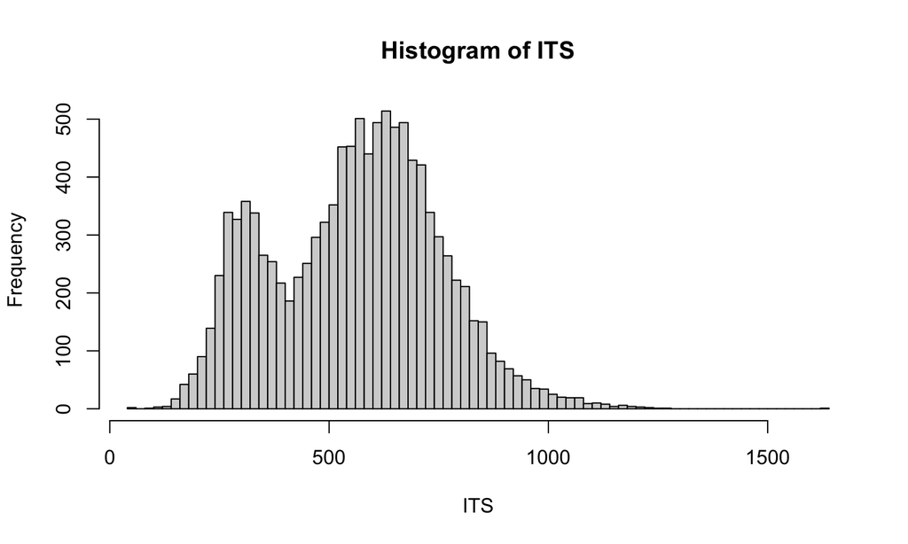

```r
NrOfBins=100
hist(ITS, breaks = NrOfBins)
```